# Nivell 1

## Exercici 1

Agafa el conjunt de dades que vulguis i realitza un pipeline i un gridsearch aplicant l'algorisme de Random Forest.

El següent dataset prové d'un estudi fet en abelles (*Apis mellifera*) on s'ha registrar l'activitat de cada individu. Els arxius contenen:

- **alive_bees**:the results of the bayesian lifetime model with one row for each bee.
- **bee_daily**: This file contains one row per bee per day that she was alive for the focal period.

A continuació s'exposa el significat de cada variable per tots dos datasets:

- **Unnamed: 0**: index column
- **bee_id** Unique integer for each bee in the hive.
- **days_alive**: Number of bees the bees was determined to be alive. If the individual was still alive at the end of the recording, the number of days from the day she hatched until the end of the recording.
- **death_observed**: Boolean indicator whether the death occurred during the recording period.
- **annotated_tagged_date**: The date on which the bee hatched (and was tagged). Hatch date of the individual, i.e. the date she was tagged.
- **inferred_death_date**: Date of death as determined by a model.
- **date**: Date in year-month-day format.
- **age**: Bee's age in days. Can be NaN if bee has no associated death_date.
- **network_age**, **network_age_1** and **network_age_2**: dimensions of network age which is a espectral descomposition of diffeerent tasks in the hive. It reflects the fraction of time spent in the task-associated areas using CCA (canonical-correlation analysis), but no represent the location in hive (Fig. 1; extracted from Wild *et al.* 2021).

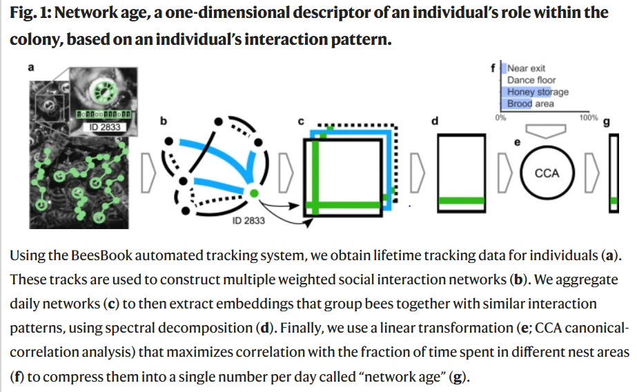

- **dance_floor**: Observed percentage of day spent on dance floor. Can be NaN if bee had no high confidence detections (>0.9) on date. Can be 0 if a bee was only seen outside of the annotated areas.
- **honey_storage**: Observed percentage of day spent in honey storage. Can be NaN if bee had no high confidence detections. Can be 0 if a bee was only seen outside of the annotated areas.
- **near_exit**: Observed percentage of day spent near exit. Can be NaN if bee had no high confidence detections (>0.9) on date. Can be 0 if a bee was only seen outside of the annotated areas.
- **brood_area_total**: Observed percentage of day spent in brood area. Can be NaN if bee had no high confidence detections (>0.9) on date. Can be 0 if a bee was only seen outside of the annotated areas.
- **location_descriptor_count**: The number of minutes the bee was seen in one of the location labels during that day. I.e., dance_floor * location_descriptor_count calculates the number of minutes, the bee was seen on the dance floor on the given day.
- **death_date**: Date the bee was last seen in the colony in year-month-day format. Can be NaN for individuals that did not die until the end of the recording period.
- **circadian_rhythm**: R² value of a sine with a period of one day fitted to the velocity data of the individual over three days. Can be NaN if the fit did not converge due to a lack of data points.
- **velocity_peak_time**: Phase of the circadian sine fit in hours as an offset to 12:00 UTC. Can be NaN if circadian_rhythm is NaN.
- **velocity_day**, **velocity_night**: Mean velocity of the individual between 09:00-18:00 UTC and 21:00-06:00 UTC, respectively. Can be NaN if no velocity data was available for that interval.
- **days_left**: Difference in days between date and death_date. Can be NaN if death_date is NaN.

The inform about the labels come from: https://zenodo.org/record/4438013#.Yp-R2OxBxPY

The data belongs to next work: Wild, B., Dormagen, D.M., Zachariae, A. et al. Social networks predict the life and death of honey bees. Nat Commun 12, 1110 (2021). https://doi.org/10.1038/s41467-021-21212-5

```python
import pandas as pd
import numpy as np
import seaborn as sns
import matplotlib.pyplot as plt
```

```python
alive_bees = pd.read_csv('C:/Users/Guillermo/Desktop/Curs Data Scientist/Sprint 12 pipeline text analisis web scraping/Bees/alive_bees_bayesian.csv')
```

```python
alive_bees.head()
```

|  | Unnamed: 0 | bee_id | days_alive | death_observed | annotated_tagged_date | inferred_death_date |
| --- | --- | --- | --- | --- | --- | --- |
| 0 | 0 | 2444 | 44.0 | True | 2016-08-01 | 2016-09-14 |
| 1 | 1 | 135 | 41.0 | True | 2016-06-29 | 2016-08-09 |
| 2 | 2 | 1016 | 38.0 | True | 2016-07-11 | 2016-08-18 |
| 3 | 3 | 1920 | 33.0 | True | 2016-07-22 | 2016-08-24 |
| 4 | 4 | 1083 | 10.0 | True | 2016-07-12 | 2016-07-22 |

```python
bee_daily = pd.read_csv('C:/Users/Guillermo/Desktop/Curs Data Scientist/Sprint 12 pipeline text analisis web scraping/Bees/bee_daily_data.csv')
bee_daily.head()
```

|  | bee_id | date | age | network_age | network_age_1 | network_age_2 | dance_floor | honey_storage | near_exit | brood_area_total | location_descriptor_count | death_date | hatch_date | circadian_rhythm | velocity_peak_time | velocity_day | velocity_night | days_left |
| --- | --- | --- | --- | --- | --- | --- | --- | --- | --- | --- | --- | --- | --- | --- | --- | --- | --- | --- |
| 0 | 2048 | 2016-08-15 | 21 | 14.117577 | 39.909297 | 39.484358 | 0.000000 | 0.474227 | 0.025773 | 0.500000 | 194.0 | 2016-08-28 | 2016-07-25 | 0.015964 | 2.293511 | 1.498729 | 1.267362 | 13.0 |
| 1 | 2049 | 2016-08-15 | 21 | 21.625170 | 29.558000 | 19.021249 | 0.083333 | 0.263889 | 0.291667 | 0.361111 | 72.0 | 2016-08-31 | 2016-07-25 | 0.040005 | 1.221958 | 2.449739 | 1.417412 | 16.0 |
| 2 | 2050 | 2016-08-15 | 21 | 7.925220 | 34.207851 | 23.408334 | 0.009404 | 0.539185 | 0.012539 | 0.438871 | 319.0 | 2016-08-27 | 2016-07-25 | 0.004777 | 1.255342 | 1.165424 | 0.950118 | 12.0 |
| 3 | 2051 | 2016-08-15 | 21 | 12.701304 | 31.005959 | 36.628877 | 0.000000 | 0.030303 | 0.121212 | 0.848485 | 33.0 | 2016-08-23 | 2016-07-25 | 0.050629 | 1.333884 | 1.938736 | 0.961636 | 8.0 |
| 4 | 2052 | 2016-08-15 | 21 | 17.447785 | 41.377717 | 9.324736 | 0.063291 | 0.101266 | 0.506329 | 0.329114 | 79.0 | 2016-09-03 | 2016-07-25 | 0.019155 | 0.737965 | 1.607989 | 0.995056 | 19.0 |

```python
bee_daily.sort_values('bee_id')
```

|  | bee_id | date | age | network_age | network_age_1 | network_age_2 | dance_floor | honey_storage | near_exit | brood_area_total | location_descriptor_count | death_date | hatch_date | circadian_rhythm | velocity_peak_time | velocity_day | velocity_night | days_left |
| --- | --- | --- | --- | --- | --- | --- | --- | --- | --- | --- | --- | --- | --- | --- | --- | --- | --- | --- |
| 21431 | 10 | 2016-08-01 | 34 | 43.179274 | 9.489744 | 73.781032 | 0.235669 | 0.019108 | 0.745223 | 0.000000 | 157.0 | 2016-08-04 | 2016-06-28 | 6.864626e-02 | 2.267546e+00 | 2.143683 | 1.676306 | 3.0 |
| 17333 | 10 | 2016-08-02 | 35 | 44.009726 | -0.454015 | 47.120567 | 0.158730 | 0.063492 | 0.777778 | 0.000000 | 126.0 | 2016-08-04 | 2016-06-28 | 2.780864e-02 | 1.888008e+00 | 1.958223 | 1.294789 | 2.0 |
| 4678 | 10 | 2016-08-03 | 36 | 49.471552 | 1.823752 | 25.799534 | 0.156863 | 0.000000 | 0.843137 | 0.000000 | 51.0 | 2016-08-04 | 2016-06-28 | 4.077228e-02 | 2.084833e+00 | 1.928135 | 1.370150 | 1.0 |
| 23798 | 10 | 2016-08-04 | 37 | 17.735955 | 29.487915 | 34.086813 | 0.000000 | 0.000000 | 0.000000 | 0.000000 | 0.0 | 2016-08-04 | 2016-06-28 | 1.337687e-01 | 2.016391e+00 | 1.827758 | 0.817387 | 0.0 |
| 19568 | 21 | 2016-08-20 | 53 | 36.680828 | 40.106079 | 30.523910 | 0.193069 | 0.024752 | 0.747525 | 0.034653 | 202.0 | 2016-08-23 | 2016-06-28 | 1.353105e-01 | 2.021858e+00 | 1.359202 | 0.378988 | 3.0 |
| ... | ... | ... | ... | ... | ... | ... | ... | ... | ... | ... | ... | ... | ... | ... | ... | ... | ... | ... |
| 17097 | 3263 | 2016-08-23 | 0 | 5.425561 | 3.607562 | -21.064441 | 0.000000 | 0.012195 | 0.000000 | 0.987805 | 82.0 | 2016-09-13 | 2016-08-23 | -6.503686e-13 | 3.374945e-18 | 1.802891 | 1.924751 | 21.0 |
| 9634 | 3263 | 2016-08-25 | 2 | 1.648004 | -6.241934 | 11.242497 | 0.000000 | 0.020725 | 0.000000 | 0.979275 | 386.0 | 2016-09-13 | 2016-08-23 | 4.676058e-04 | 4.998681e-22 | 1.655893 | 1.607520 | 19.0 |
| 25660 | 3264 | 2016-08-24 | 1 | -3.907336 | 22.076323 | 35.943835 | 0.000000 | 0.002075 | 0.002075 | 0.995851 | 482.0 | 2016-08-26 | 2016-08-23 | 5.095924e-13 | 1.449598e-23 | 2.089242 | 2.115560 | 2.0 |
| 17098 | 3264 | 2016-08-23 | 0 | -4.455485 | 12.992258 | 64.706926 | 0.000000 | 0.000000 | 0.000000 | 1.000000 | 104.0 | 2016-08-26 | 2016-08-23 | 1.658484e-03 | 8.689212e-11 | 2.159676 | 2.152003 | 3.0 |
| 9635 | 3264 | 2016-08-25 | 2 | 2.612355 | 4.337724 | 7.043915 | 0.011628 | 0.093023 | 0.000000 | 0.895349 | 258.0 | 2016-08-26 | 2016-08-23 | 4.089336e-03 | 4.648966e-01 | 2.091347 | 1.861293 | 1.0 |

26762 rows × 18 columns

```python
alive_bees.sort_values('bee_id')
```

|  | Unnamed: 0 | bee_id | days_alive | death_observed | annotated_tagged_date | inferred_death_date |
| --- | --- | --- | --- | --- | --- | --- |
| 1904 | 1914 | 9 | 27.0 | True | 2016-06-28 | 2016-07-25 |
| 1402 | 1410 | 10 | 38.0 | True | 2016-06-28 | 2016-08-05 |
| 1062 | 1070 | 17 | 26.0 | True | 2016-06-28 | 2016-07-24 |
| 425 | 426 | 21 | 57.0 | True | 2016-06-28 | 2016-08-24 |
| 409 | 410 | 22 | 41.0 | True | 2016-06-28 | 2016-08-08 |
| ... | ... | ... | ... | ... | ... | ... |
| 1375 | 1383 | 3260 | 25.0 | True | 2016-08-23 | 2016-09-17 |
| 1951 | 1962 | 3261 | 16.0 | True | 2016-08-23 | 2016-09-08 |
| 1068 | 1076 | 3262 | 14.0 | True | 2016-08-23 | 2016-09-06 |
| 434 | 435 | 3263 | 22.0 | True | 2016-08-23 | 2016-09-14 |
| 1910 | 1920 | 3264 | 4.0 | True | 2016-08-23 | 2016-08-27 |

2430 rows × 6 columns

```python
table =  bee_daily['bee_id'].value_counts()
t2 = alive_bees['bee_id'].value_counts()
```

```python
print(type(table))
print(type(t2))
```

```
<class 'pandas.core.series.Series'>
<class 'pandas.core.series.Series'>
```

```python
print(len(table))
print(len(t2))
```

```
1920
2430
```

### Exploració de les dades

```python
bee_daily.describe()
```

|  | bee_id | age | network_age | network_age_1 | network_age_2 | dance_floor | honey_storage | near_exit | brood_area_total | location_descriptor_count | circadian_rhythm | velocity_peak_time | velocity_day | velocity_night | days_left |
| --- | --- | --- | --- | --- | --- | --- | --- | --- | --- | --- | --- | --- | --- | --- | --- |
| count | 26762.000000 | 26762.000000 | 26762.000000 | 26762.000000 | 26762.000000 | 26574.000000 | 26574.000000 | 26574.000000 | 26574.000000 | 26574.000000 | 2.670100e+04 | 2.670100e+04 | 26701.000000 | 26700.000000 | 26575.000000 |
| mean | 2041.621254 | 16.618526 | 17.099833 | 21.400314 | 19.567008 | 0.176235 | 0.116657 | 0.229149 | 0.476792 | 210.419357 | 8.079667e-02 | 1.417472e+00 | 2.278498 | 1.266873 | 11.325569 |
| std | 708.210454 | 11.108224 | 13.828811 | 12.641685 | 12.542470 | 0.226930 | 0.168185 | 0.266889 | 0.374685 | 149.484363 | 8.658058e-02 | 6.190501e-01 | 0.720541 | 0.459953 | 8.505487 |
| min | 10.000000 | 0.000000 | -6.199047 | -52.359734 | -70.735590 | 0.000000 | 0.000000 | 0.000000 | 0.000000 | 0.000000 | -3.203485e-09 | 4.006211e-51 | 0.549015 | 0.209983 | 0.000000 |
| 25% | 1573.000000 | 7.000000 | 4.730311 | 12.665251 | 11.869126 | 0.004963 | 0.006250 | 0.004878 | 0.073654 | 106.000000 | 1.333238e-02 | 1.107709e+00 | 1.792525 | 0.918521 | 4.000000 |
| 50% | 2157.000000 | 15.000000 | 13.342027 | 22.295336 | 19.203572 | 0.057692 | 0.040000 | 0.099136 | 0.465042 | 171.000000 | 4.257022e-02 | 1.472342e+00 | 2.167262 | 1.207604 | 10.000000 |
| 75% | 2592.000000 | 25.000000 | 30.368674 | 31.054125 | 26.950307 | 0.294550 | 0.157895 | 0.418320 | 0.868421 | 270.000000 | 1.323396e-01 | 1.795922e+00 | 2.633387 | 1.565057 | 17.000000 |
| max | 3264.000000 | 58.000000 | 55.178546 | 77.005595 | 117.715414 | 1.000000 | 1.000000 | 1.000000 | 1.000000 | 1062.000000 | 4.900427e-01 | 4.597630e+00 | 8.514614 | 4.199075 | 48.000000 |

Les variables dance_floor, honey_storage, near_exit i brood_area_total contenen el tant per cent de temps que ha passat l'abella realitzant una tasca concreta. Sent normal que el mínim sigui 0 y el màxim 1. Com es normal al major part de temps s'inverteix en la zona de cria mentre que en la resta d'activitats es veu més reduïda. Sent aquesta on hi ha una major variància de les dades, mentre que a la resta aquesta variabilitat en la distribució és menor. Per un altre costat, location_descriptor_count mostra el temps que passa cada abella en una de les tasques concretes.

circadian_rhythm explica com la velocitat de la abella varia en funció del ritme circadiari a través d'una funció sinusoidal. Segons les dades obtingudes sembla que mostra gran variabilitat entre els diferents individus.

days_left correspón a la diferència entre el dia que es va fer el registre i el dia que va morir l'abella.

```python
bee_daily.head()
```

|  | bee_id | date | age | network_age | network_age_1 | network_age_2 | dance_floor | honey_storage | near_exit | brood_area_total | location_descriptor_count | death_date | hatch_date | circadian_rhythm | velocity_peak_time | velocity_day | velocity_night | days_left |
| --- | --- | --- | --- | --- | --- | --- | --- | --- | --- | --- | --- | --- | --- | --- | --- | --- | --- | --- |
| 0 | 2048 | 2016-08-15 | 21 | 14.117577 | 39.909297 | 39.484358 | 0.000000 | 0.474227 | 0.025773 | 0.500000 | 194.0 | 2016-08-28 | 2016-07-25 | 0.015964 | 2.293511 | 1.498729 | 1.267362 | 13.0 |
| 1 | 2049 | 2016-08-15 | 21 | 21.625170 | 29.558000 | 19.021249 | 0.083333 | 0.263889 | 0.291667 | 0.361111 | 72.0 | 2016-08-31 | 2016-07-25 | 0.040005 | 1.221958 | 2.449739 | 1.417412 | 16.0 |
| 2 | 2050 | 2016-08-15 | 21 | 7.925220 | 34.207851 | 23.408334 | 0.009404 | 0.539185 | 0.012539 | 0.438871 | 319.0 | 2016-08-27 | 2016-07-25 | 0.004777 | 1.255342 | 1.165424 | 0.950118 | 12.0 |
| 3 | 2051 | 2016-08-15 | 21 | 12.701304 | 31.005959 | 36.628877 | 0.000000 | 0.030303 | 0.121212 | 0.848485 | 33.0 | 2016-08-23 | 2016-07-25 | 0.050629 | 1.333884 | 1.938736 | 0.961636 | 8.0 |
| 4 | 2052 | 2016-08-15 | 21 | 17.447785 | 41.377717 | 9.324736 | 0.063291 | 0.101266 | 0.506329 | 0.329114 | 79.0 | 2016-09-03 | 2016-07-25 | 0.019155 | 0.737965 | 1.607989 | 0.995056 | 19.0 |

```python
bee_daily.sort_values(by = ['bee_id', 'date']).head(30)
```

|  | bee_id | date | age | network_age | network_age_1 | network_age_2 | dance_floor | honey_storage | near_exit | brood_area_total | location_descriptor_count | death_date | hatch_date | circadian_rhythm | velocity_peak_time | velocity_day | velocity_night | days_left |
| --- | --- | --- | --- | --- | --- | --- | --- | --- | --- | --- | --- | --- | --- | --- | --- | --- | --- | --- |
| 21431 | 10 | 2016-08-01 | 34 | 43.179274 | 9.489744 | 73.781032 | 0.235669 | 0.019108 | 0.745223 | 0.000000 | 157.0 | 2016-08-04 | 2016-06-28 | 0.068646 | 2.267546 | 2.143683 | 1.676306 | 3.0 |
| 17333 | 10 | 2016-08-02 | 35 | 44.009726 | -0.454015 | 47.120567 | 0.158730 | 0.063492 | 0.777778 | 0.000000 | 126.0 | 2016-08-04 | 2016-06-28 | 0.027809 | 1.888008 | 1.958223 | 1.294789 | 2.0 |
| 4678 | 10 | 2016-08-03 | 36 | 49.471552 | 1.823752 | 25.799534 | 0.156863 | 0.000000 | 0.843137 | 0.000000 | 51.0 | 2016-08-04 | 2016-06-28 | 0.040772 | 2.084833 | 1.928135 | 1.370150 | 1.0 |
| 23798 | 10 | 2016-08-04 | 37 | 17.735955 | 29.487915 | 34.086813 | 0.000000 | 0.000000 | 0.000000 | 0.000000 | 0.0 | 2016-08-04 | 2016-06-28 | 0.133769 | 2.016391 | 1.827758 | 0.817387 | 0.0 |
| 21445 | 21 | 2016-08-01 | 34 | 40.709857 | 14.031431 | 22.399087 | 0.183616 | 0.008475 | 0.805085 | 0.002825 | 354.0 | 2016-08-23 | 2016-06-28 | 0.268422 | 2.021410 | 2.764000 | 0.899181 | 22.0 |
| 17347 | 21 | 2016-08-02 | 35 | 43.347252 | -6.497340 | 20.566019 | 0.226415 | 0.000000 | 0.773585 | 0.000000 | 212.0 | 2016-08-23 | 2016-06-28 | 0.242284 | 2.192690 | 2.162661 | 0.910307 | 21.0 |
| 4692 | 21 | 2016-08-03 | 36 | 31.587698 | 11.929923 | -16.245054 | 0.750000 | 0.000000 | 0.136364 | 0.113636 | 44.0 | 2016-08-23 | 2016-06-28 | 0.189979 | 2.493180 | 1.518371 | 0.891178 | 20.0 |
| 23812 | 21 | 2016-08-04 | 37 | 37.716029 | 20.470592 | 10.680490 | 0.258824 | 0.011765 | 0.717647 | 0.011765 | 85.0 | 2016-08-23 | 2016-06-28 | 0.135942 | 2.332643 | 1.586124 | 1.041745 | 19.0 |
| 11814 | 21 | 2016-08-05 | 38 | 31.348544 | 52.518578 | 72.808477 | 0.172662 | 0.028777 | 0.741007 | 0.057554 | 139.0 | 2016-08-23 | 2016-06-28 | 0.141362 | 1.555979 | 1.976217 | 0.402420 | 18.0 |
| 3485 | 21 | 2016-08-06 | 39 | 32.251565 | 23.933251 | 3.082064 | 0.552632 | 0.000000 | 0.289474 | 0.157895 | 38.0 | 2016-08-23 | 2016-06-28 | 0.222564 | 1.284789 | 2.686788 | 0.381642 | 17.0 |
| 6012 | 21 | 2016-08-07 | 40 | 24.634546 | 20.065268 | 30.971177 | 0.281250 | 0.015625 | 0.687500 | 0.015625 | 64.0 | 2016-08-23 | 2016-06-28 | 0.221213 | 1.320311 | 2.547300 | 0.370203 | 16.0 |
| 14309 | 21 | 2016-08-08 | 41 | 25.863187 | 40.645508 | 31.780514 | 0.215190 | 0.025316 | 0.696203 | 0.063291 | 79.0 | 2016-08-23 | 2016-06-28 | 0.092699 | 1.904783 | 1.532621 | 0.499408 | 15.0 |
| 10796 | 21 | 2016-08-09 | 42 | 31.673725 | 27.007720 | 22.949204 | 0.840426 | 0.021277 | 0.106383 | 0.031915 | 94.0 | 2016-08-23 | 2016-06-28 | 0.087131 | 1.788454 | 1.389363 | 0.380157 | 14.0 |
| 22699 | 21 | 2016-08-10 | 43 | 36.436678 | 30.556698 | 8.363918 | 0.433628 | 0.004425 | 0.508850 | 0.053097 | 226.0 | 2016-08-23 | 2016-06-28 | 0.090057 | 1.884174 | 1.254392 | 0.372948 | 13.0 |
| 13079 | 21 | 2016-08-11 | 44 | 27.426572 | 31.679273 | 12.569162 | 0.166667 | 0.000000 | 0.642857 | 0.190476 | 42.0 | 2016-08-23 | 2016-06-28 | 0.130816 | 1.700245 | 1.664417 | 0.397104 | 12.0 |
| 2279 | 21 | 2016-08-12 | 45 | 39.026776 | 5.910744 | 34.048820 | 0.119048 | 0.004762 | 0.819048 | 0.057143 | 210.0 | 2016-08-23 | 2016-06-28 | 0.168806 | 1.857730 | 1.983328 | 0.493423 | 11.0 |
| 7953 | 21 | 2016-08-13 | 46 | 29.301096 | 14.417866 | 34.606980 | 0.156863 | 0.156863 | 0.509804 | 0.176471 | 51.0 | 2016-08-23 | 2016-06-28 | 0.155259 | 2.156065 | 2.113583 | 0.773853 | 10.0 |
| 1167 | 21 | 2016-08-14 | 47 | 35.618073 | 8.678201 | 30.803245 | 0.448819 | 0.000000 | 0.488189 | 0.062992 | 127.0 | 2016-08-23 | 2016-06-28 | 0.093626 | 2.350787 | 2.028828 | 0.848795 | 9.0 |
| 17 | 21 | 2016-08-15 | 48 | 32.283695 | 18.088980 | 14.782174 | 0.785714 | 0.000000 | 0.125000 | 0.089286 | 112.0 | 2016-08-23 | 2016-06-28 | 0.077283 | 2.715996 | 1.445074 | 0.693419 | 8.0 |
| 15377 | 21 | 2016-08-16 | 49 | 34.722796 | 17.393372 | 46.881864 | 0.300971 | 0.000000 | 0.684466 | 0.014563 | 206.0 | 2016-08-23 | 2016-06-28 | 0.114328 | 2.651158 | 1.265178 | 0.461867 | 7.0 |
| 20420 | 21 | 2016-08-17 | 50 | 35.801888 | 6.122155 | 32.647807 | 0.570000 | 0.000000 | 0.380000 | 0.050000 | 100.0 | 2016-08-23 | 2016-06-28 | 0.149067 | 2.676148 | 1.030283 | 0.486242 | 6.0 |
| 9827 | 21 | 2016-08-18 | 51 | 26.218877 | 31.328204 | 16.855027 | 0.520000 | 0.013333 | 0.346667 | 0.120000 | 75.0 | 2016-08-23 | 2016-06-28 | 0.167977 | 2.352789 | 1.293288 | 0.411313 | 5.0 |
| 25874 | 21 | 2016-08-19 | 52 | 30.997084 | 18.695107 | 32.533133 | 0.226415 | 0.018868 | 0.716981 | 0.037736 | 106.0 | 2016-08-23 | 2016-06-28 | 0.134194 | 2.026653 | 1.460448 | 0.444537 | 4.0 |
| 19568 | 21 | 2016-08-20 | 53 | 36.680828 | 40.106079 | 30.523910 | 0.193069 | 0.024752 | 0.747525 | 0.034653 | 202.0 | 2016-08-23 | 2016-06-28 | 0.135311 | 2.021858 | 1.359202 | 0.378988 | 3.0 |
| 7130 | 21 | 2016-08-21 | 54 | 40.375967 | 1.952699 | 21.778046 | 0.119904 | 0.038369 | 0.834532 | 0.007194 | 417.0 | 2016-08-23 | 2016-06-28 | 0.105555 | 2.021756 | 1.239256 | 0.380505 | 2.0 |
| 18683 | 21 | 2016-08-22 | 55 | 40.868655 | 24.269184 | 30.315785 | 0.199546 | 0.004535 | 0.793651 | 0.002268 | 441.0 | 2016-08-23 | 2016-06-28 | 0.116283 | 1.944944 | 1.446701 | 0.392224 | 1.0 |
| 16458 | 21 | 2016-08-23 | 56 | 43.367465 | 6.475955 | 25.137756 | 0.128492 | 0.000000 | 0.865922 | 0.005587 | 179.0 | 2016-08-23 | 2016-06-28 | 0.084743 | 1.841574 | 1.562976 | 0.468421 | 0.0 |
| 21442 | 22 | 2016-08-01 | 34 | 45.444014 | 1.219010 | 16.130220 | 0.586207 | 0.005747 | 0.408046 | 0.000000 | 174.0 | 2016-08-07 | 2016-06-28 | 0.327208 | 1.600493 | 4.075632 | 0.859072 | 6.0 |
| 17344 | 22 | 2016-08-02 | 35 | 45.417335 | 7.583612 | 5.024047 | 0.320896 | 0.007463 | 0.671642 | 0.000000 | 268.0 | 2016-08-07 | 2016-06-28 | 0.332931 | 1.384760 | 3.973586 | 0.742959 | 5.0 |
| 4689 | 22 | 2016-08-03 | 36 | 48.109597 | -7.856879 | -25.517200 | 0.654206 | 0.000000 | 0.345794 | 0.000000 | 107.0 | 2016-08-07 | 2016-06-28 | 0.306770 | 1.446938 | 3.542070 | 0.781911 | 4.0 |

A més, l'objectiu d'aquest estudi serà intentar predir el temps que es passen les abelles emmagatzemant mel. Sent aquesta la variable resultant o depenent del model.

Per un altre costat, es decideix tractar cada fila com a individu diferent com a primera aproximació perquè el que fa una abella a mesura que passen els dies varia suficient com per poder-ho analitzar com si fossin individus diferents.

També s'eliminarà la columna date i days_left, ja que no es creu que poguin aportar informació al model perquè la primera mostra el dia que es van recollir les dades mentre que la segona la distància en temps entre el dia de la mesura i el dia de la mort. El mateix passa amb death_date i hatch_date

```python
bee = bee_daily.drop(['date', 'days_left', 'death_date', 'hatch_date'], axis = 1)
print(bee_daily.shape, bee.shape)
```

```
(26762, 18) (26762, 14)
```

```python
bee_names = bee.columns
```

```python
len(bee_names)
```

```
14
```

```python
len(bee_names[1:])
```

```
13
```

```python
bee_names
```

```
Index(['bee_id', 'age', 'network_age', 'network_age_1', 'network_age_2',
       'dance_floor', 'honey_storage', 'near_exit', 'brood_area_total',
       'location_descriptor_count', 'circadian_rhythm', 'velocity_peak_time',
       'velocity_day', 'velocity_night'],
      dtype='object')
```

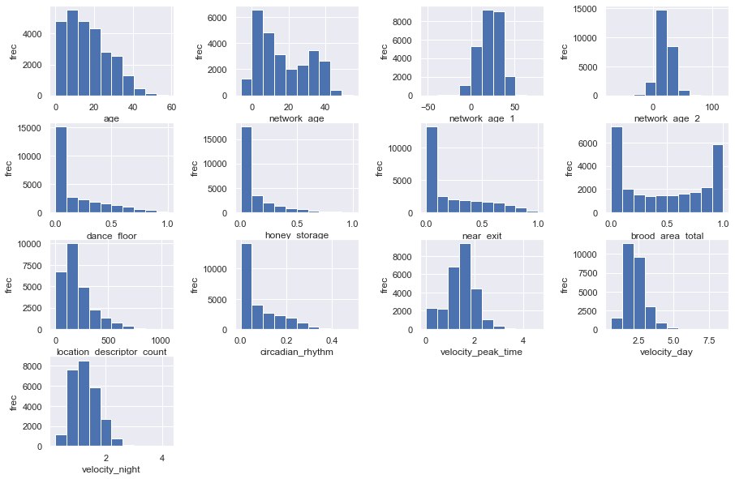

```python
sns.set()
plt.figure(figsize = (15,10))

for i, name in enumerate(bee_names[1:]):
    plt.subplot(4,4,(i+1))
    plt.hist(bee[name])
    plt.xlabel(name)
    plt.ylabel('frec')

plt.subplots_adjust(hspace=0.3, wspace = 0.5)
plt.show()
```

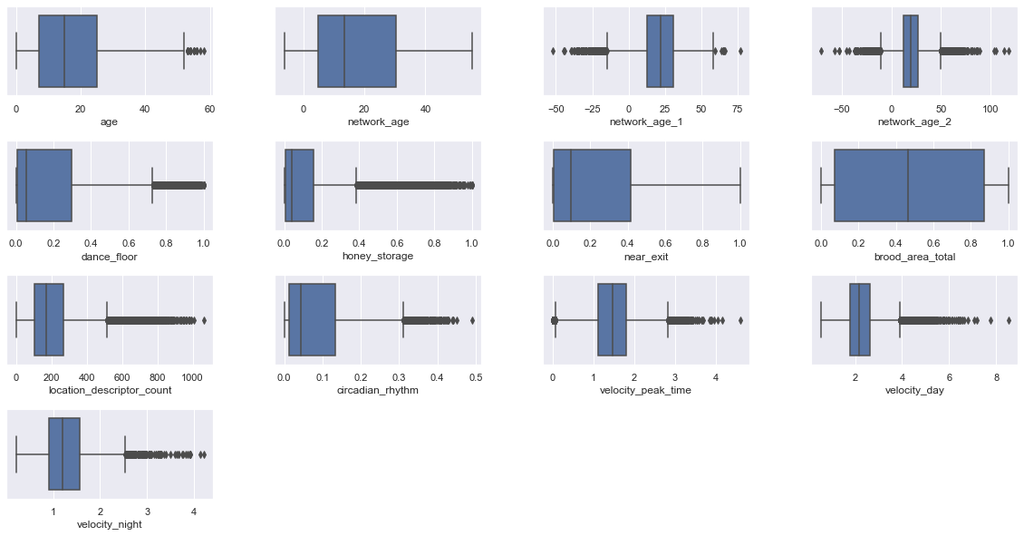

```python
sns.set()
plt.figure(figsize = (20,10))

for i, name in enumerate(bee_names[1:]):
    plt.subplot(4,4,(i+1))
    sns.boxplot(x = bee[name])
    plt.xlabel(name)


plt.subplots_adjust(hspace=0.5, wspace = 0.3)
plt.show()
```

```python
bee.isna().sum()
```

```
bee_id                         0
age                            0
network_age                    0
network_age_1                  0
network_age_2                  0
dance_floor                  188
honey_storage                188
near_exit                    188
brood_area_total             188
location_descriptor_count    188
circadian_rhythm              61
velocity_peak_time            61
velocity_day                  61
velocity_night                62
dtype: int64
```

Com el número de NaNs és molt s'eliminaran els NaNs. Això permetre disminuir el soroll que es podria produir al substituit NaNs per valors

```python
bee2 = bee.dropna(axis = 0)
print(bee.shape, bee2.shape)
```

```
(26762, 14) (26564, 14)
```

```python
print(bee.shape[0] - bee2.shape[0])
print((bee.shape[0] - bee2.shape[0])/len(bee)*100)
print(len(bee2))
```

```
198
0.7398550183095434
26564
```

Per tant al final no s'utilitzarà un total de 198 observacions que corresponen al 0.74% del dataframe. Passant a tenir 26564 observacions.

### Construcció de la pipeline

```python
from sklearn.model_selection import train_test_split

x = bee2.drop('honey_storage', axis =1)
y = bee2.loc[:,'honey_storage']

train_x, test_x, train_y, test_y = train_test_split(x,y, train_size=0.8, random_state=42)

print(train_x.shape, test_x.shape, train_y.shape, test_y.shape)
```

```
(21251, 13) (5313, 13) (21251,) (5313,)
```

```python
from sklearn.pipeline import Pipeline
from sklearn.ensemble import RandomForestRegressor
from sklearn.preprocessing import RobustScaler

pipeline1 = Pipeline(steps = [('robustScaler', RobustScaler()),
                             ('forest', RandomForestRegressor(n_estimators = 50, max_depth=10, random_state=42))
                             ])

from sklearn.model_selection import GridSearchCV

parameters = {'forest__criterion':['squared_error', 'absolute_error', 'poisson'],
             #'forest__max_features':['auto','sqrt','log2']
             }

grid = GridSearchCV(pipeline1, param_grid=parameters, cv = 5)

grid.fit(train_x, train_y)

print(grid.best_params_)
```

```
{'forest__criterion': 'squared_error'}
```

```python
y_predict = grid.predict(test_x)
```

```python
from sklearn.metrics import r2_score

r2_score(test_y, y_predict)
```

```
0.945471508478506
```

El model aplicat de random forest regression en el que porta integrat cross validation retorna un valor de 0.9 de $R^2$. Per tant, els valors obtinguts s'acosten molt a la realitat.

## Exercici 2

Agafa un text en anglès que vulguis, i calcula'n la freqüència de les paraules

```python
text2 = '''Barcelona city council detects 360 illegal tourist apartments
Barcelona mayor Colau announces the post-pandemic reactivation of the action plan against illegal tourist flats

The tourists are back, and so are some of the problems of the sector's huge presence in Barcelona. This Friday, the mayor of Barcelona, Ada Colau, announced the reactivation of the shock plan against illegal tourist flats, a plan created under the current municipal government that gave good results and put an end to the uncontrolled proliferation of this activity. "With the recovery of tourism after the pandemic, we do not want this activity to return to the city," said Colau, who recalled that economic activity "works better if it is regulated." She mae the announcement at a press conference alongside with Femke Halsema, the mayor of Amsterdam, with whom she had met to address the challenges shared by the two cities, including the regulation of tourism.

According to the city council, the reactivation of the plan has allowed a team of more than 70 people to get to work, including 25 "viewers" who do their job on the street, to prevent the return of the illegal activity. More than 21,000 ads have already been tracked on digital platforms, and some 360 flats have been detected offering tourist activity without permission. The accommodation platforms will be asked to immediately withdraw these announcements and the corresponding procedure will be initiated, which could end with fines of between 3,000 and 60,000 euros. It is also planned to launch an information campaign to remind visitors not to stay in unlicenced flats, and to tell the public that tourist accommodation services cannot be offered without permission.
Barcelona and Amsterdam, allies

As well, Colau expressed her gratitude at the press conference that Amsterdam, a city that is an economic motor of Europe, with a powerful economic hub and strong tourist traction, is working together with the Catalan capital to exchange experiences and knowledge. In fact, the two cities have been working together for some time and have developed similar policies, such as the regulation of hotels in the centre and a sustained fight against the activity of illegal tourist flats, as well as curbing overcrowding and committing to a sustainable tourism that looks to the future.

The mayor of Amsterdam praised Barcelona's leadership and the commitment of the two capitals to work in a network and in coordination with other European cities. Femke Halsema has also come out in favour of limiting the activity of airports, especially with regard to short flights that have an alternative by rail. The mayor of Amsterdam emphasized the importance of continuing to collaborate and share experiences in order to work for sustainable and non-crowded tourist activity. The two mayors also spoke about the situations of the airport and the port in their respective cities.

Jordi Palmer
Barcelona. Friday, 10 June 2022. 22:54
El nacional.cat '''
```

```python
from nltk.tokenize import word_tokenize
tokens = word_tokenize(text2)
print(tokens)
```

```
['Barcelona', 'city', 'council', 'detects', '360', 'illegal', 'tourist', 'apartments', 'Barcelona', 'mayor', 'Colau', 'announces', 'the', 'post-pandemic', 'reactivation', 'of', 'the', 'action', 'plan', 'against', 'illegal', 'tourist', 'flats', 'The', 'tourists', 'are', 'back', ',', 'and', 'so', 'are…
```

```python
from nltk.probability import FreqDist

frec = FreqDist(tokens)
```

```python
frec.most_common(6)
```

```
[('the', 39), (',', 27), ('of', 23), ('to', 20), ('and', 17), ('.', 16)]
```

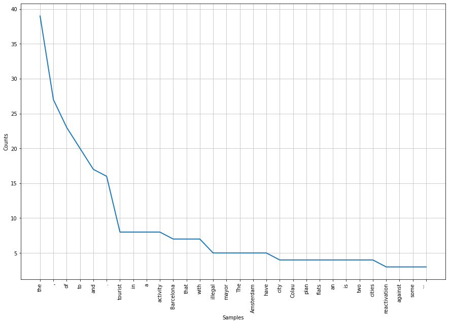

```python
plt.figure(figsize=(15,10))
frec.plot(30, cumulative=False)
plt.show()
```

En l'anàlisi de freqüències s'observa que les paraules més repetides son the, of, to, i and. Havent d'afegir signes ortogràfics com el punt. Per tant es farà un anàlisis extra traient les stopwords

```python
#nltk.download('stopwords')
from nltk.corpus import stopwords
stopWords = set(stopwords.words('english'))

filter_sent = []
for word in tokens:
    if word not in stopWords:
        filter_sent.append(word)
```

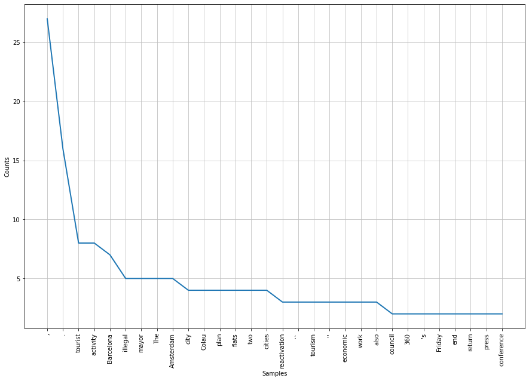

```python
plt.figure(figsize=(15,10))
frec_filter = FreqDist(filter_sent)
frec_filter.plot(30, cumulative=False)
plt.show()
```

Un cop eliminades les stopwords es veu com es comença a focalitzar en el cos del text. Tot i així els signes ortogràfics continuen estant al capdavant.

```python
pip freeze
```

[output not shown]

[output cut: 248 more lines]

[output not shown]